# Analysis of PCA on CLR

# Hierarchial Clustering

Another early step in many microbiome projects to examine how samples cluster on some measure of taxonomic (dis)similarity. There are MANY ways to do perform such clustering. Here I present just one approach that I assume many of you are familiar with. We will perform hierarchal clustering of samples based on their Bray-Curtis dissimilarity. * as two samples share fewer taxa, the number increases * 0 for samples that have the exact same composition * 1 for those sharing no taxa.

It is also worth remembering that this is a measure of dissimilarity (it is not a true distance measure).

```r
#Extract OTU table and compute BC
ps_rel_otu <- data.frame(phyloseq::otu_table(ps_rel_abund))
ps_rel_otu <- t(ps_rel_otu)
bc_dist <- vegan::vegdist(ps_rel_otu, method = "bray")
as.matrix(bc_dist)[1:5, 1:5]
```

```
            sC0C     s1C03A     s1C03B    s1C05A    s1C05B
sC0C   0.0000000 0.33628013 0.35900239 0.4319964 0.3317772
s1C03A 0.3362801 0.00000000 0.07275557 0.3006468 0.1727207
s1C03B 0.3590024 0.07275557 0.00000000 0.3326331 0.1925381
s1C05A 0.4319964 0.30064682 0.33263311 0.0000000 0.2644793
s1C05B 0.3317772 0.17272075 0.19253812 0.2644793 0.0000000
```

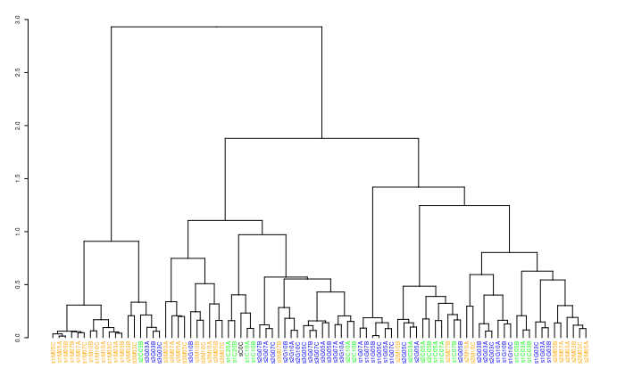

```r
#Save as dendrogram
ward <- as.dendrogram(hclust(bc_dist, method = "ward.D2"))
#Provide color codes
meta <- data.frame(phyloseq::sample_data(ps_rel_abund))
colorCode <- c(sC = "green", sM = "orange", sG = "blue")
labels_colors(ward) <- colorCode[meta$series][order.dendrogram(ward)]
#Plot
par(cex = 0.4)
plot(ward)
```

# Beta Diversity

- Employ a compositional data analysis approach and involves working with log-ratios.
- At a high-level compositional data (i.e. data that carry only relative information and are constrained by a unit sum) exist in a restricted subspace of the Euclidian geometry referred to as the D-1 simplex (I know this doesn’t feel high-level).
- Due to this constraint, these data fail to meet many of the assumptions of our favorite statistical methods developed for unconstrained random variables.
- Working with ratios of compositional elements lets us transform these data to the Euclidian space and apply our favorite methods (so we don’t need to work in the simplex).
- Working with their logarithms makes them easier to interpret.

There are different types of log-ratio “transformations” including the additive log-ratio, centered log-ratio, and isometric log-ratio transforms. Below are some great resources for learning more about compositional data analysis:

*[Understanding sequencing data as compositions: an outlook and review](https://academic.oup.com/bioinformatics/article/34/16/2870/4956011) by Quinn et. al. in Bioinformatics (2018)

*[Statistical Analysis of Microbiome Data with R - Ch. 10](https://www.springer.com/us/book/9789811315336?gclid=Cj0KCQjw3uboBRDCARIsAO2XcYAphJ23am-AoIBh18HoW-WpAd8TwbQUEhc_DJV9gM-zWYtXe0-6l8saAkNHEALw_wcB)

*[Applied Compositional Data Analysis](https://www.springer.com/gp/book/9783319964201) by Filzmoser, Hron, and Templ (2018)

*[Analyzing Compositional Data with R](https://www.springer.com/gp/book/9783642368080) by Boogaart and Tolosana-Delgado (2013)

```r
#CLR transform
(ps_clr <- microbiome::transform(ps, "clr"))
```

```
phyloseq-class experiment-level object
otu_table()   OTU Table:         [ 561 taxa and 86 samples ]
sample_data() Sample Data:       [ 86 samples by 7 sample variables ]
tax_table()   Taxonomy Table:    [ 561 taxa by 7 taxonomic ranks ]
phy_tree()    Phylogenetic Tree: [ 561 tips and 559 internal nodes ]
```

```r
phyloseq::otu_table(ps)[1:5, 1:5]
```

```
OTU Table:          [5 taxa and 5 samples]
                     taxa are rows
        sC0C s1C03A s1C03B s1C05A s1C05B
OTU_471    8      4      7      5      7
OTU_620   61     34     41     32     79
OTU_640 4270   2662   3657   2136   4412
OTU_403    5      3      2      1      1
OTU_162    1      1      0      1      0
```

```r
phyloseq::otu_table(ps_clr)[1:5, 1:5]
```

```
OTU Table:          [5 taxa and 5 samples]
                     taxa are rows
             sC0C    s1C03A     s1C03B    s1C05A    s1C05B
OTU_471 2.0841393 1.8529848  1.8919424 1.7931247  1.595103
OTU_620 4.0905765 3.9519464  3.6235648 3.6128864  3.976933
OTU_640 8.3352988 8.3068802  8.1068926 7.8070297  7.995494
OTU_403 1.6310389 1.5804017  0.7405748 0.3407615 -0.112634
OTU_162 0.1860856 0.5950153 -1.2619501 0.3407615 -1.509966
```

We can see that the values are now no longer counts, but rather the dominance (or lack thereof) for each taxa relative to the geometric mean of all taxa on the logarithmic scale (any log base could be used and often log2 or log10 may aid in interpretation).

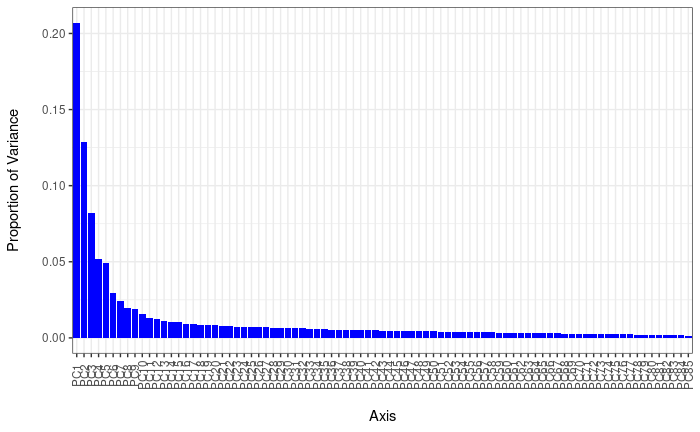

```r
#PCA via phyloseq
ord_clr <- phyloseq::ordinate(ps_clr, "RDA")
#Plot scree plot
phyloseq::plot_scree(ord_clr) +
  geom_bar(stat="identity", fill = "blue") +
  labs(x = "\nAxis", y = "Proportion of Variance\n")
```

```r
# Examine eigenvalues and % prop. variance explained
head(ord_clr$CA$eig)
```

```
      PC1       PC2       PC3       PC4       PC5       PC6
101.97779  63.48435  40.54782  25.55857  24.14612  14.47207
```

```r
sapply(ord_clr$CA$eig[1:5], function(x) x / sum(ord_clr$CA$eig))
```

```
       PC1        PC2        PC3        PC4        PC5
0.20684271 0.12876603 0.08224361 0.05184073 0.04897586
```

```
Too few points to calculate an ellipse
Warning: Removed 1 row(s) containing missing values (geom_path).
```

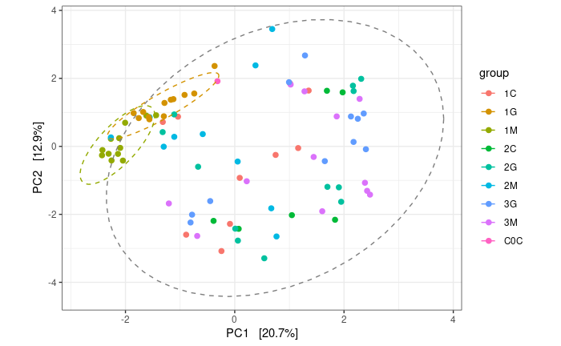

```r
#Scale axes and plot ordination
clr1 <- ord_clr$CA$eig[1] / sum(ord_clr$CA$eig)
clr2 <- ord_clr$CA$eig[2] / sum(ord_clr$CA$eig)
phyloseq::plot_ordination(ps, ord_clr, type="samples", color="group") +
  geom_point(size = 2) +
  coord_fixed(clr2 / clr1) +
  stat_ellipse(aes(group = carbon), linetype = 2)
```

```
Too few points to calculate an ellipse
Warning: Removed 1 row(s) containing missing values (geom_path).
```

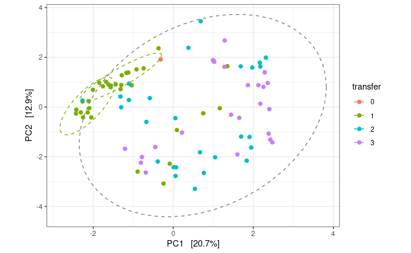

```r
#Scale axes and plot ordination
clr1 <- ord_clr$CA$eig[1] / sum(ord_clr$CA$eig)
clr2 <- ord_clr$CA$eig[2] / sum(ord_clr$CA$eig)
phyloseq::plot_ordination(ps, ord_clr, type="samples", color="transfer") +
  geom_point(size = 2) +
  coord_fixed(clr2 / clr1) +
  stat_ellipse(aes(group = carbon), linetype = 2)
```

```
Too few points to calculate an ellipse
Warning: Removed 1 row(s) containing missing values (geom_path).
```

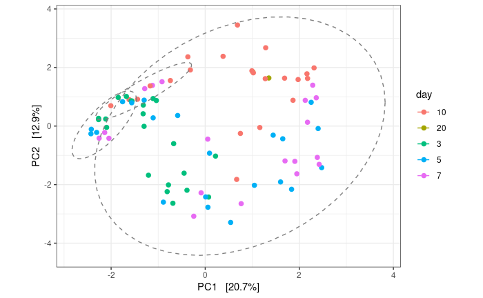

```r
#Scale axes and plot ordination
clr1 <- ord_clr$CA$eig[1] / sum(ord_clr$CA$eig)
clr2 <- ord_clr$CA$eig[2] / sum(ord_clr$CA$eig)
phyloseq::plot_ordination(ps, ord_clr, type="samples", color="day") +
  geom_point(size = 2) +
  coord_fixed(clr2 / clr1) +
  stat_ellipse(aes(group = carbon), linetype = 2)
```

# Pretty CLR + PCA Plot

```
Too few points to calculate an ellipse
Warning: Removed 1 row(s) containing missing values (geom_path).
```

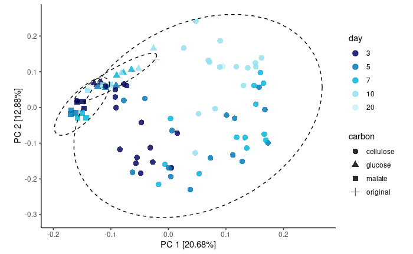

```r
# make data frame
clr_pca.data <- data.frame(PC1=ord_clr$CA$u[,1], PC2=ord_clr$CA$u[,2])
meta <- data.frame(phyloseq::sample_data(ps))
clr_pca.data <- merge(clr_pca.data, meta, by="row.names")
clr_pca.data$day <- as.factor(clr_pca.data$day)

# plot
clr1 <- ord_clr$CA$eig[1] / sum(ord_clr$CA$eig)
clr2 <- ord_clr$CA$eig[2] / sum(ord_clr$CA$eig)
ggplot(clr_pca.data, aes(x = PC1, y = PC2)) +
  theme_classic() +
  geom_point(
    mapping = aes(colour = day, shape = carbon),
    size = 3,
    alpha = 5/6
  ) +
  coord_fixed(clr2 / clr1) +
  stat_ellipse(aes(group = carbon), linetype = 2) +
  scale_color_manual(values = c(
  "3" = "#03045e",
  "5" = "#0077b6",
  "7" = "#00b4d8",
  "10" = "#90e0ef",
  "20" = "#caf0f8"
)) +
  xlab(sprintf("PC 1 [%s%%]", round(100 * clr1, 2))) +
  ylab(sprintf("PC 2 [%s%%]", round(100 * clr2, 2)))
```

Check clustering dendogram for patterns

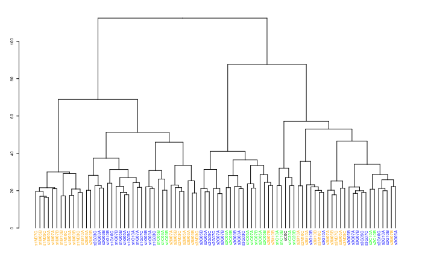

```r
ps_clr_otu <- data.frame(phyloseq::otu_table(ps_clr))
ps_clr_otu <- t(ps_clr_otu)
bc_dist_clr <- vegan::vegdist(ps_clr_otu,  method = "euclidean")
#Save as dendrogram
ward <- as.dendrogram(hclust(bc_dist_clr, method = "ward.D2"))
#Provide color codes
meta <- data.frame(phyloseq::sample_data(ps_rel_abund))
colorCode <- c(sC = "green", sM = "orange", sG = "blue")
labels_colors(ward) <- colorCode[meta$series][order.dendrogram(ward)]
#Plot
par(cex = 0.4)
plot(ward)
```

Check that results are robust to sub-sampling only samples on cellulose

```r
(ps_cellulose_clr <- microbiome::transform(ps_cellulose, "clr"))
```

```
phyloseq-class experiment-level object
otu_table()   OTU Table:         [ 558 taxa and 61 samples ]
sample_data() Sample Data:       [ 61 samples by 7 sample variables ]
tax_table()   Taxonomy Table:    [ 558 taxa by 7 taxonomic ranks ]
phy_tree()    Phylogenetic Tree: [ 558 tips and 556 internal nodes ]
```

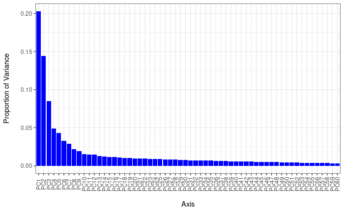

```r
#PCA via phyloseq
ord_cellulose_clr <- phyloseq::ordinate(ps_cellulose_clr, "RDA")
#Plot scree plot
phyloseq::plot_scree(ord_cellulose_clr) +
  geom_bar(stat="identity", fill = "blue") +
  labs(x = "\nAxis", y = "Proportion of Variance\n")
```

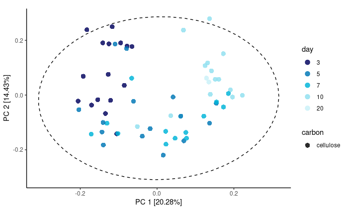

```r
# make data frame
clr_pca.data <- data.frame(PC1=ord_cellulose_clr$CA$u[,1], PC2=ord_cellulose_clr$CA$u[,2])
meta <- data.frame(phyloseq::sample_data(ps))
clr_pca.data <- merge(clr_pca.data, meta, by="row.names")
clr_pca.data$day <- as.factor(clr_pca.data$day)

# plot
clr1 <- ord_cellulose_clr$CA$eig[1] / sum(ord_cellulose_clr$CA$eig)
clr2 <- ord_cellulose_clr$CA$eig[2] / sum(ord_cellulose_clr$CA$eig)
ggplot(clr_pca.data, aes(x = PC1, y = PC2)) +
  theme_classic() +
  geom_point(
    mapping = aes(colour = day, shape = carbon),
    size = 3,
    alpha = 5/6
  ) +
  coord_fixed(clr2 / clr1) +
  stat_ellipse(aes(group = carbon), linetype = 2) +
  scale_color_manual(values = c(
  "3" = "#03045e",
  "5" = "#0077b6",
  "7" = "#00b4d8",
  "10" = "#90e0ef",
  "20" = "#caf0f8"
)) +
  xlab(sprintf("PC 1 [%s%%]", round(100 * clr1, 2))) +
  ylab(sprintf("PC 2 [%s%%]", round(100 * clr2, 2)))
```

```r
(ps_cellulose_clr <- microbiome::transform(ps_cellulose, "clr"))
```

```
phyloseq-class experiment-level object
otu_table()   OTU Table:         [ 558 taxa and 61 samples ]
sample_data() Sample Data:       [ 61 samples by 7 sample variables ]
tax_table()   Taxonomy Table:    [ 558 taxa by 7 taxonomic ranks ]
phy_tree()    Phylogenetic Tree: [ 558 tips and 556 internal nodes ]
```

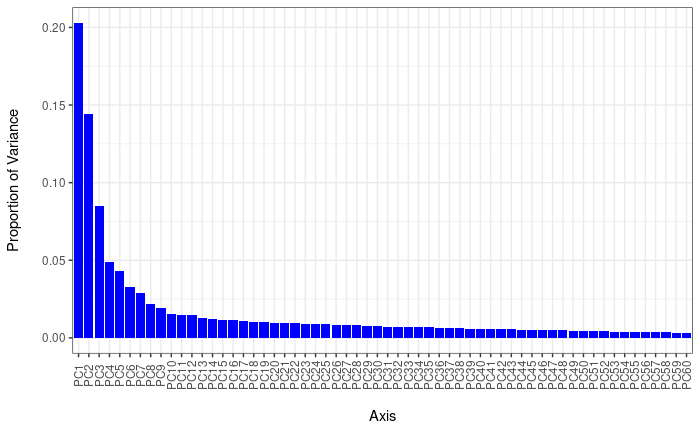

```r
#PCA via phyloseq
ord_cellulose_clr <- phyloseq::ordinate(ps_cellulose_clr, "RDA")
#Plot scree plot
phyloseq::plot_scree(ord_cellulose_clr) +
  geom_bar(stat="identity", fill = "blue") +
  labs(x = "\nAxis", y = "Proportion of Variance\n")
```

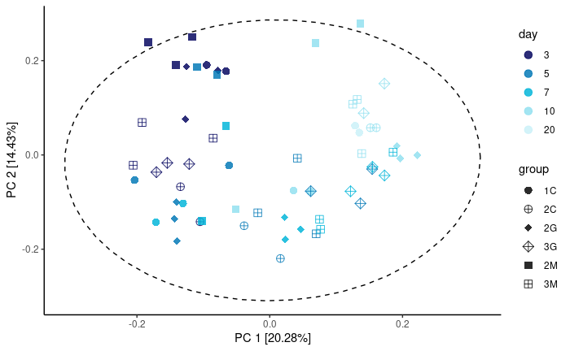

```r
# make data frame
clr_pca.data <- data.frame(PC1=ord_cellulose_clr$CA$u[,1], PC2=ord_cellulose_clr$CA$u[,2])
meta <- data.frame(phyloseq::sample_data(ps))
clr_pca.data <- merge(clr_pca.data, meta, by="row.names")
clr_pca.data$day <- as.factor(clr_pca.data$day)

# plot
clr1 <- ord_cellulose_clr$CA$eig[1] / sum(ord_cellulose_clr$CA$eig)
clr2 <- ord_cellulose_clr$CA$eig[2] / sum(ord_cellulose_clr$CA$eig)
ggplot(clr_pca.data, aes(x = PC1, y = PC2)) +
  theme_classic() +
  geom_point(
    mapping = aes(colour = day, shape = group),
    size = 3,
    alpha = 5/6
  ) +
  coord_fixed(clr2 / clr1) +
  stat_ellipse(aes(group = carbon), linetype = 2) +
  scale_color_manual(values = c(
  "3" = "#03045e",
  "5" = "#0077b6",
  "7" = "#00b4d8",
  "10" = "#90e0ef",
  "20" = "#caf0f8"
)) +
  scale_shape_manual(values = c(
  "1C" = 16,
  "2C" = 10,
  "2G" = 18,
  "3G" = 9,
  "2M" = 15,
  "3M" = 12
)) +
  xlab(sprintf("PC 1 [%s%%]", round(100 * clr1, 2))) +
  ylab(sprintf("PC 2 [%s%%]", round(100 * clr2, 2)))
```

```
Too few points to calculate an ellipse
Warning: Removed 1 row(s) containing missing values (geom_path).
```

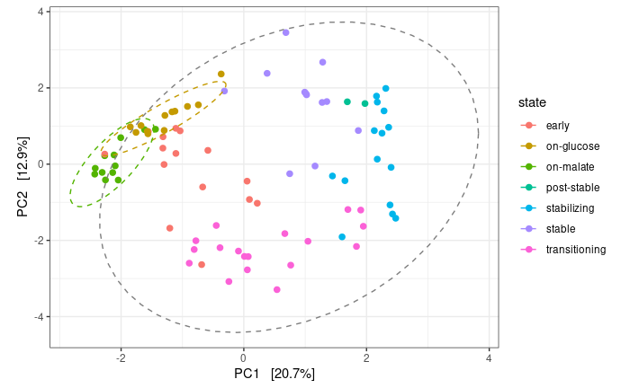

```r
#Scale axes and plot ordination
clr1 <- ord_clr$CA$eig[1] / sum(ord_clr$CA$eig)
clr2 <- ord_clr$CA$eig[2] / sum(ord_clr$CA$eig)
phyloseq::plot_ordination(ps, ord_clr, type="samples", color="state") +
  geom_point(size = 2) +
  coord_fixed(clr2 / clr1) +
  stat_ellipse(aes(group = carbon), linetype = 2)
```

# Compare With PCA on Bray-Curtis

```r
#PCA via phyloseq
ord_bc <- phyloseq::ordinate(ps_rel_abund, "PCoA", "bray")
bc_pca.data <- data.frame(PC1=ord_bc$vectors[,1], PC2=ord_bc$vectors[,2])
meta <- data.frame(phyloseq::sample_data(ps_rel_abund))
(bc_pca.data <- merge(bc_pca.data, meta, by="row.names"))
```

| Row.names | PC1 | PC2 | group | series | carbon | transfer | day | replicate | state |
| --- | --- | --- | --- | --- | --- | --- | --- | --- | --- |
| s1C03A | 0.007971166 | 0.012787093 | 1C | sC | cellulose | 1 | 3 | A | early |
| s1C03B | -0.013360039 | 0.020025565 | 1C | sC | cellulose | 1 | 3 | B | early |
| s1C05A | 0.084887171 | -0.106800003 | 1C | sC | cellulose | 1 | 5 | A | transitioning |
| s1C05B | -0.074933722 | -0.080789226 | 1C | sC | cellulose | 1 | 5 | B | early |
| s1C07A | -0.033529221 | -0.110732771 | 1C | sC | cellulose | 1 | 7 | A | transitioning |
| s1C07B | 0.071512206 | -0.131449312 | 1C | sC | cellulose | 1 | 7 | B | transitioning |
| s1C10A | -0.171973551 | -0.133151529 | 1C | sC | cellulose | 1 | 10 | A | stable |
| s1C10B | -0.144839067 | -0.140353346 | 1C | sC | cellulose | 1 | 10 | B | stable |
| s1C20A | -0.156307686 | -0.044105543 | 1C | sC | cellulose | 1 | 20 | A | stable |
| s1C20B | -0.243540990 | -0.096055831 | 1C | sC | cellulose | 1 | 20 | B | stable |

[output cut: 76 more lines]

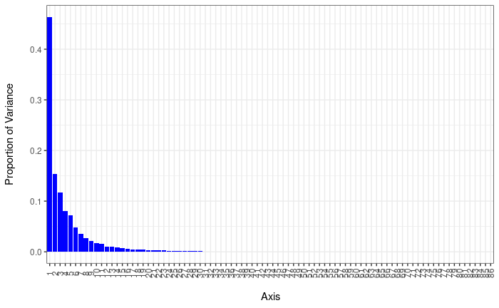

```r
bc_pca.data$day <- as.factor(bc_pca.data$day)
#Plot scree plot
phyloseq::plot_scree(ord_bc) +
  geom_bar(stat="identity", fill = "blue") +
  labs(x = "\nAxis", y = "Proportion of Variance\n")
```

```r
# Examine eigenvalues and % prop. variance explained
head(ord_bc$values$Eigenvalues)
```

```
[1] 5.7118904 1.8911229 1.4429847 0.9929695 0.8948544 0.5921577
```

```r
sapply(ord_bc$values$Eigenvalues[1:5], function(x) x / sum(ord_bc$values$Eigenvalues))
```

```
[1] 0.46369179 0.15352153 0.11714163 0.08060936 0.07264436
```

```
Too few points to calculate an ellipse
Warning: Removed 1 row(s) containing missing values (geom_path).
```

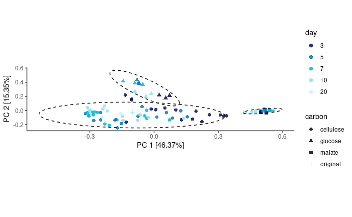

```r
clr1 <- ord_bc$values$Eigenvalues[1] / sum(ord_bc$values$Eigenvalues)
clr2 <- ord_bc$values$Eigenvalues[2] / sum(ord_bc$values$Eigenvalues)
ggplot(bc_pca.data, aes(x = PC1, y = PC2)) +
  theme_classic() +
  geom_point(
    mapping = aes(colour = day, shape = carbon),
    size = 2,
    alpha = 5/6
  ) +
  coord_fixed(clr2 / clr1) +
  stat_ellipse(aes(group = carbon), linetype = 2) +
  scale_color_manual(values = c(
  "3" = "#03045e",
  "5" = "#0077b6",
  "7" = "#00b4d8",
  "10" = "#90e0ef",
  "20" = "#caf0f8"
)) +
  xlab(sprintf("PC 1 [%s%%]", round(100 * clr1, 2))) +
  ylab(sprintf("PC 2 [%s%%]", round(100 * clr2, 2)))
```

```r
# Generate distance matrix
ps_cellulose_rel_abund <- phyloseq::subset_samples(ps_rel_abund, carbon =="cellulose")
ps_cellulose_rel_abund <- phyloseq::prune_taxa(phyloseq::taxa_sums(ps_cellulose_rel_abund) > 0, ps_cellulose_rel_abund)
ord_bc_cellulose <- phyloseq::ordinate(ps_cellulose_rel_abund, "PCoA", "bray")
bc_pca_cellulose.data <- data.frame(PC1=ord_bc_cellulose$vectors[,1], PC2=ord_bc_cellulose$vectors[,2])
meta <- data.frame(phyloseq::sample_data(ps_cellulose_rel_abund))
(bc_pca_cellulose.data <- merge(bc_pca_cellulose.data, meta, by="row.names"))
```

| Row.names | PC1 | PC2 | group | series | carbon | transfer | day | replicate | state |
| --- | --- | --- | --- | --- | --- | --- | --- | --- | --- |
| s1C03A | -0.138549966 | -0.283363528 | 1C | sC | cellulose | 1 | 3 | A | early |
| s1C03B | -0.123228280 | -0.309028543 | 1C | sC | cellulose | 1 | 3 | B | early |
| s1C05A | -0.251982261 | -0.017936038 | 1C | sC | cellulose | 1 | 5 | A | transitioning |
| s1C05B | -0.073714724 | -0.116449943 | 1C | sC | cellulose | 1 | 5 | B | early |
| s1C07A | -0.138783706 | -0.041550472 | 1C | sC | cellulose | 1 | 7 | A | transitioning |
| s1C07B | -0.242077175 | 0.046171069 | 1C | sC | cellulose | 1 | 7 | B | transitioning |
| s1C10A | 0.113253058 | -0.008191460 | 1C | sC | cellulose | 1 | 10 | A | stable |
| s1C10B | 0.085611275 | 0.010026228 | 1C | sC | cellulose | 1 | 10 | B | stable |
| s1C20A | 0.172967105 | -0.003067490 | 1C | sC | cellulose | 1 | 20 | A | stable |
| s1C20B | 0.264337694 | -0.002703616 | 1C | sC | cellulose | 1 | 20 | B | stable |

[output cut: 51 more lines]

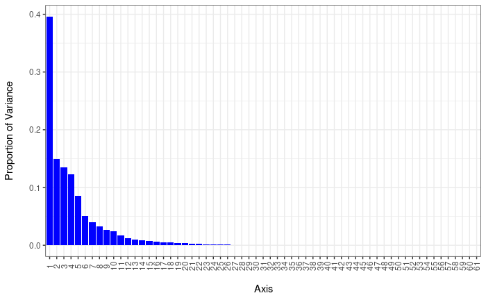

```r
bc_pca_cellulose.data$day <- as.factor(bc_pca_cellulose.data$day)
#Plot scree plot
phyloseq::plot_scree(ord_bc_cellulose) +
  geom_bar(stat="identity", fill = "blue") +
  labs(x = "\nAxis", y = "Proportion of Variance\n")
```

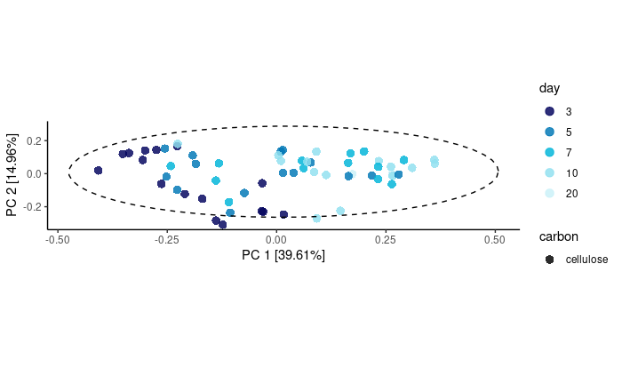

```r
# plot
clr1 <- ord_bc_cellulose$values$Eigenvalues[1] / sum(ord_bc_cellulose$values$Eigenvalues)
clr2 <- ord_bc_cellulose$values$Eigenvalues[2] / sum(ord_bc_cellulose$values$Eigenvalues)
ggplot(bc_pca_cellulose.data, aes(x = PC1, y = PC2)) +
  theme_classic() +
  geom_point(
    mapping = aes(colour = day, shape = carbon),
    size = 3,
    alpha = 5/6
  ) +
  coord_fixed(clr2 / clr1) +
  stat_ellipse(aes(group = carbon), linetype = 2) +
  scale_color_manual(values = c(
  "3" = "#03045e",
  "5" = "#0077b6",
  "7" = "#00b4d8",
  "10" = "#90e0ef",
  "20" = "#caf0f8"
)) +
  xlab(sprintf("PC 1 [%s%%]", round(100 * clr1, 2))) +
  ylab(sprintf("PC 2 [%s%%]", round(100 * clr2, 2)))
```

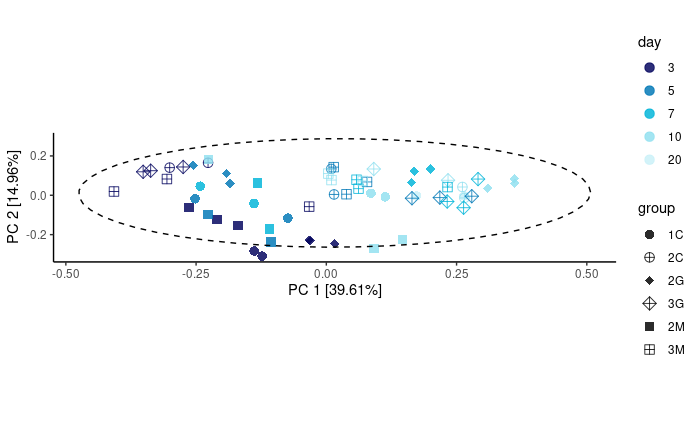

```r
# plot
clr1 <- ord_bc_cellulose$values$Eigenvalues[1] / sum(ord_bc_cellulose$values$Eigenvalues)
clr2 <- ord_bc_cellulose$values$Eigenvalues[2] / sum(ord_bc_cellulose$values$Eigenvalues)
ggplot(bc_pca_cellulose.data, aes(x = PC1, y = PC2)) +
  theme_classic() +
  geom_point(
    mapping = aes(colour = day, shape = group),
    size = 3,
    alpha = 5/6
  ) +
  coord_fixed(clr2 / clr1) +
  stat_ellipse(aes(group = carbon), linetype = 2) +
  scale_color_manual(values = c(
  "3" = "#03045e",
  "5" = "#0077b6",
  "7" = "#00b4d8",
  "10" = "#90e0ef",
  "20" = "#caf0f8"
)) +
  scale_shape_manual(values = c(
  "1C" = 16,
  "2C" = 10,
  "2G" = 18,
  "3G" = 9,
  "2M" = 15,
  "3M" = 12
)) +
  xlab(sprintf("PC 1 [%s%%]", round(100 * clr1, 2))) +
  ylab(sprintf("PC 2 [%s%%]", round(100 * clr2, 2)))
```